# Practice Problems: Shiny UI Editor

Author

Chengyu, Yijia & Sickandar

## Step 1: Get Base Shiny App

Get the codes of our base shiny app [here](https://raw.githubusercontent.com/ChengyuYangSMU/ShinyUiEditor/main/Geyser/app.R). Then load it into Shiny UI Editor using `shinyuieditor::launch_editor(app_loc = "your_file_path")`.

## Step 2: Basic Functions

Remove card headers of `Table` and `Interactive Plot`.

Change the main title from `Geyser!` to `Faithful Geyser Explorer`, and make it centered.

## Step 3: Introducing Variable Selection

In `Settings` card, add an input selector allowing users to choose between variables (`waiting` and `eruptions`).

Modify your codes in R so both the histogram and table outputs can respond to the variable selector and other elements in `Settings`.

## Step 4: Layout Control

Our current layout has three main sections:

- Header
- Sidebar (with controls)
- Main area (for plots and tables)

Modify current layout and make it more readable. Hint:

```r
"header header header"
"sidebar plotly bluePlot"
"sidebar table table"
```

Also remember to adjust `row_sizes()` and `col_sizes()` in both R and editor.

## Step 5: Final Polishing

Change the title of `bluePlot` to `Histogram of variable_names`.

Test responsive resizing by stretching and shrinking the browser window.

**Your final app should have:**

- A centered title,
- A sidebar with three controls,
- Two histograms (base + plotly),
- A reactive table showing selected rows.

Your final app should look like this:

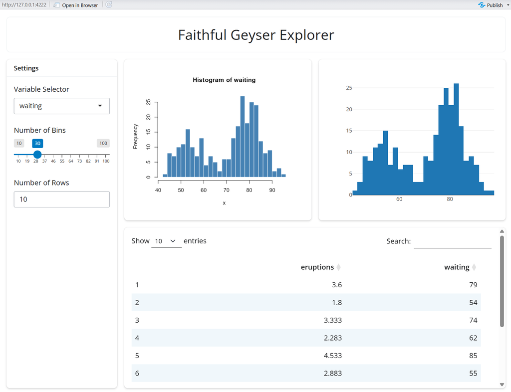

## Solution

```r
library(shiny)
library(plotly)
library(DT)
library(gridlayout)

ui <- grid_page(
  layout = c(
    "header header header",
    "sidebar plotly bluePlot",
    "sidebar table table"
  ),
  row_sizes = c("80px", "1fr", "1fr"),
  col_sizes = c("250px", "1fr", "1fr"),
  gap_size = "1rem",

  grid_card_text(area = "header", content = "Faithful Geyser Explorer", alignment = "center"),

  grid_card(
    area = "sidebar",
    card_header("Settings"),
    card_body(
      selectInput("var", "Variable Selector", choices = c("waiting", "eruptions")),
      sliderInput("bins", "Number of Bins", 10, 100, 30),
      numericInput("rows", "Number of Rows", 10, min = 1, max = nrow(faithful))
    )
  ),

  grid_card_plot(area = "plotly", outputId = "basePlot"),
  grid_card(area = "bluePlot", card_body(plotlyOutput("interactivePlot"))),
  grid_card(area = "table", card_body(DTOutput("dataTable")))
)

server <- function(input, output) {
  output$basePlot <- renderPlot({
    x <- faithful[[input$var]]
    hist(x, breaks = input$bins, col = "steelblue", border = "white",
         main = paste("Histogram of", input$var))
  })
  output$interactivePlot <- renderPlotly({
    plot_ly(x = faithful[[input$var]], type = "histogram", nbinsx = input$bins)
  })
  output$dataTable <- renderDT({
    head(faithful, input$rows)
  })
}

shinyApp(ui, server)
```